# Homework 11 - mobile app interactivity

Author

Even Pham

Published

April 14, 2024

- [LINK to GITHUB](https://github.com/cmsc-vcu/cmsc475-sp2024-hw10-BowedKinkajou50)
- [LINK to FIGMA](https://www.figma.com/file/TULFrDwTbNoVbWLqzHglKM/Untitled?type=design&node-id=0-1&mode=design&t=MJfnTKIsKQrha9Yz-0)
- [LINK to Snack Editor](https://snack.expo.dev/@bowedkinkajou50/first-screen-475?platform=ios)
- [Link to Second Snack Editor](https://snack.expo.dev/@bowedkinkajou50/second-snack)

# Overview

- AnimalFact prioritizes user satisfaction by ensuring a seamless and frustration-free experience. The app’s intuitive design eliminates the need for complicated instructions, allowing users to navigate effortlessly. With a format similar to Instagram, users can easily access different screens and enjoy scrolling through a wide array of adorable animal content.

# Key features

- Educational Content: AnimalFact offers users the opportunity to learn more about different animals as they scroll through the app. Each image is accompanied by informative text, allowing users to gain knowledge about their favorite pets or potential new companions.
- User-Friendly Interface: The app features an intuitive and easy-to-navigate interface, reminiscent of popular social media platforms like Instagram. Users can access additional screens through a hotbar and seamlessly scroll through images and videos.
- Engaging Experience: AnimalFact aims to provide an enjoyable experience for users, allowing them to explore a variety of cute animal pictures while simultaneously learning interesting facts about them.

# Storyboard of AnimalFact

[interactive chart not shown]

### wireframe design

[interactive chart not shown]

# Individual screen details

## Component 1 - starting page

### Interactivity on this screen

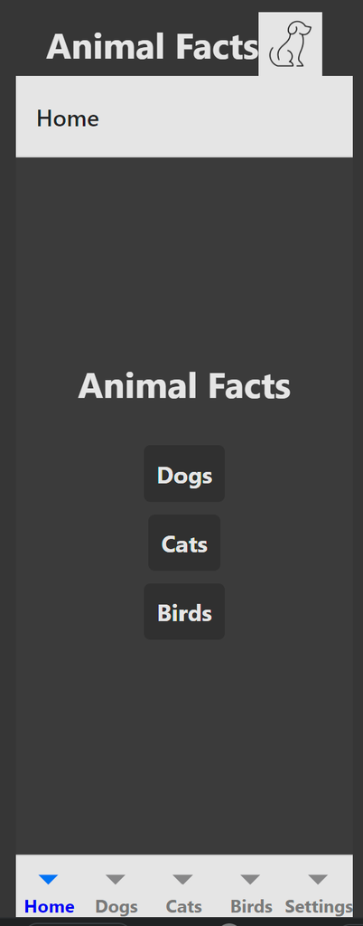

Starting page with dark mode, this can lead you into the 3 pages with animal facts.

### wireframe design

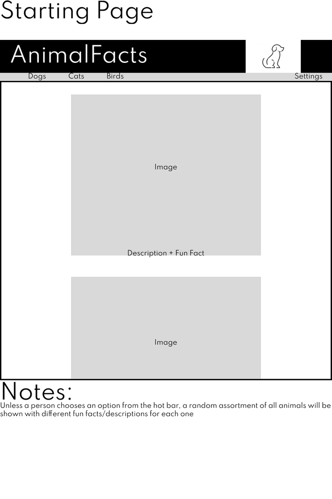

This is where you end up when you open the app, access to all animal content is in this page

-Make sure all animal api’s are working on this page and that scrolling down gives a random animal picture/video to show up -Focus on the screen itself, the border area will not be in the actual (most likely)

### As-built screenshot

This is the new Opening Screen.

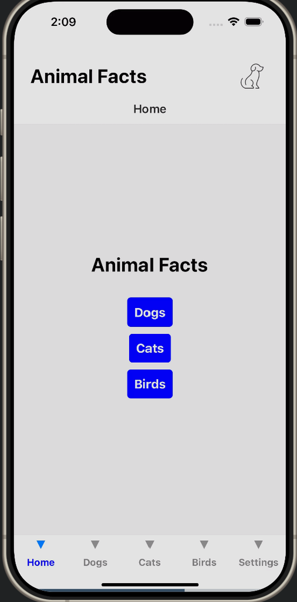

## Component 2 - Dogs

### Interactivity on this screen

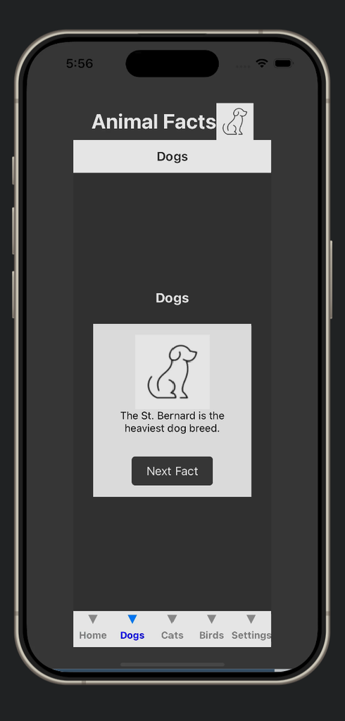

New fact button added where it calls a Dog API.

### wireframe design

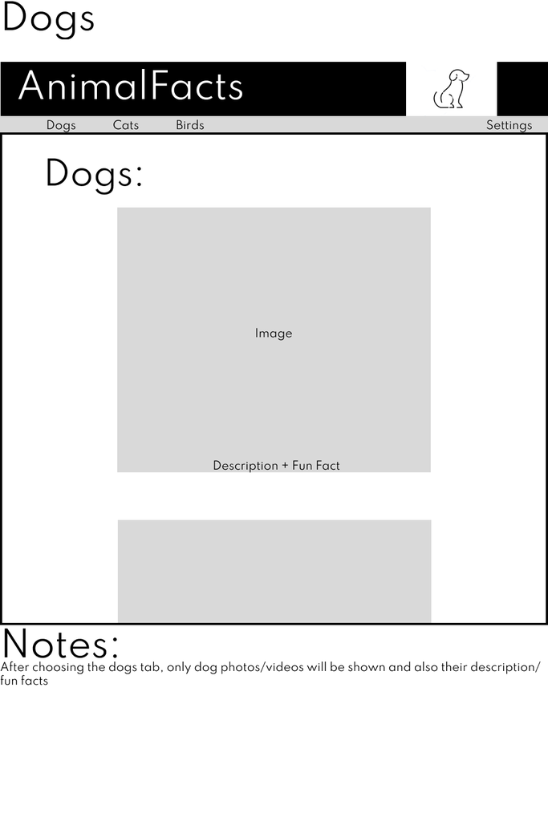

When you click on this tab on the hot bar, access to **only** dog photos/videos will be shown

- only dog based apis
- APIS: https://place.dog/, https://kinduff.github.io/dog-api/, https://dukengn.github.io/Dog-facts-API/, https://shibe.online/

### As-built screenshot

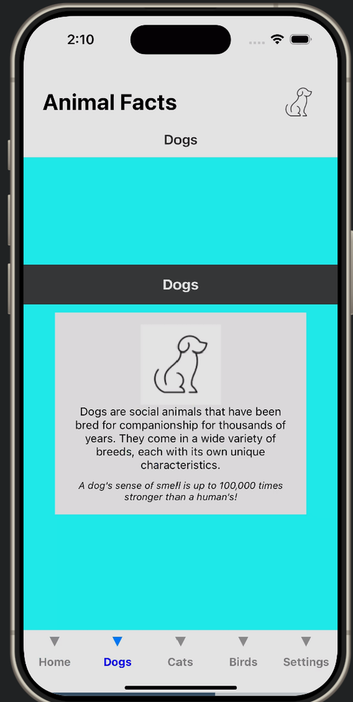

## Component 3 - Cats

### Interactivity on this screen

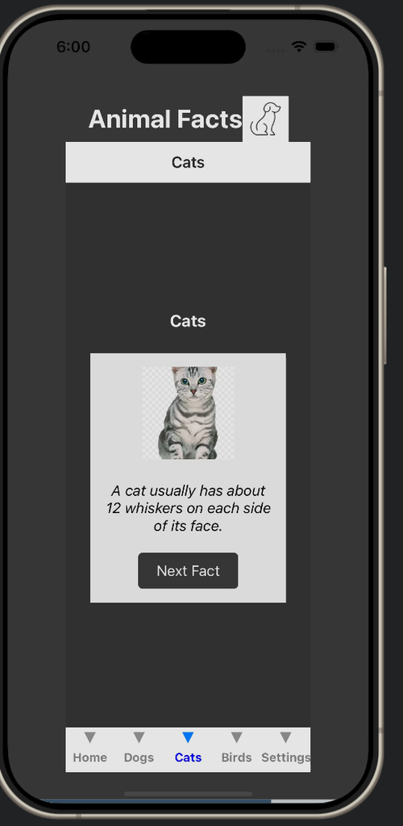

New fact button added where it calls a Cat API.

### wireframe design

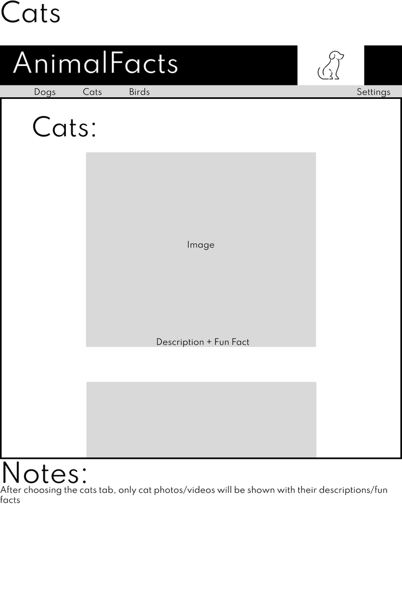

When you click on this tab on the hot bar, access to **only** cat photos/videos will be shown

- only cat based apis
- APIS: https://cataas.com/, https://cat-fact.herokuapp.com/#/, https://catfact.ninja/#/Facts/getFacts

### As-built screenshot

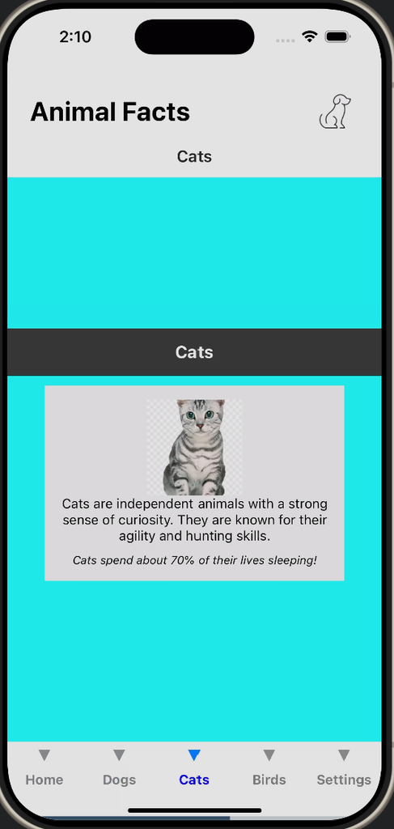

## Component 4 - Birds

### Interactivity on this screen

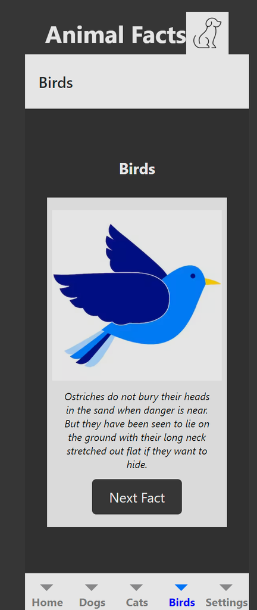

New fact button added where it calls a Bird API.

### wireframe design

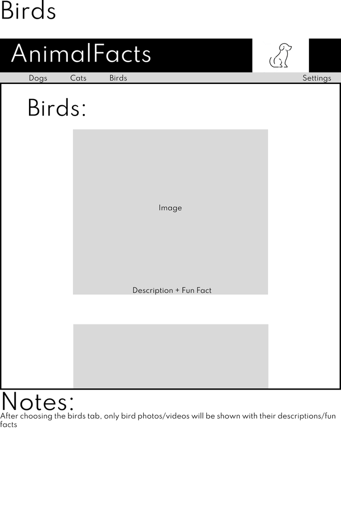

When you click on this tab on the hot bar, access to **only** bird photos/videos will be shown

- only bird based apis
- APIS: https://random-d.uk/api, https://github.com/bog-walk/random-bird, https://some-random-api.ml/endpoints/facts/bird

### As-built screenshot

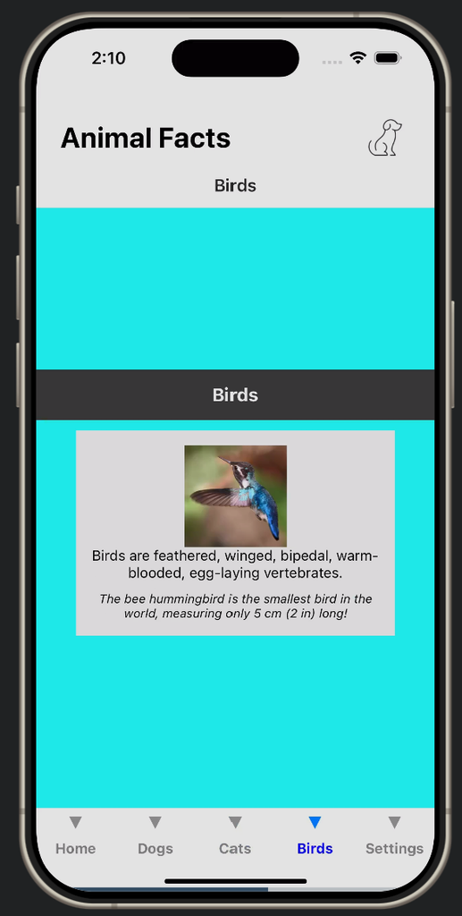

## Component 5 - Settings page

### Interactivity on this screen

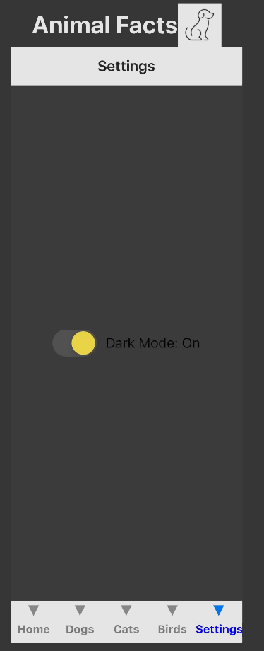

Functioning DarkMode changing the rest of the screens.

### wireframe design

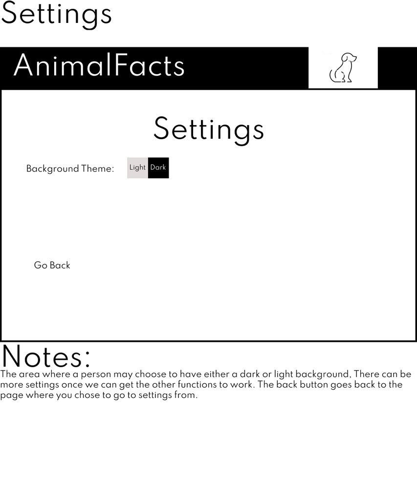

When you click on this tab on the hot bar, you will gain access to the settings where you can turn on dark/light mode

-Simple change to color scheme for all screens once dark/light mode is clicked

### As-built screenshot

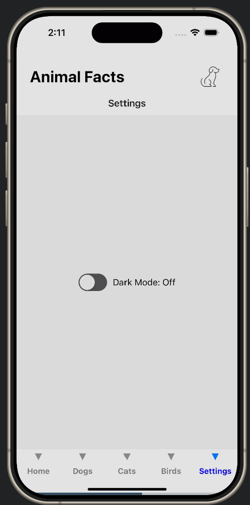

# Reflection